# Loblolly Data Exercises

Jason Holderieath

December 11, 2017

## The Data

`R` includes a dataset that may be more instructive than examples that can be calculated by hand. First, load the packages you expect to need, in this case `library(ggplot2)`. The `Loblolly` dataset can be loaded:

```r
library(ggplot2)
data("Loblolly")
Loblolly
```

```
##    height age Seed
## 1    4.51   3  301
## 15  10.89   5  301
## 29  28.72  10  301
## 43  41.74  15  301
## 57  52.70  20  301
## 71  60.92  25  301
## 2    4.55   3  303
## 16  10.92   5  303
## 30  29.07  10  303
## 44  42.83  15  303
## 58  53.88  20  303
## 72  63.39  25  303
## 3    4.79   3  305
## 17  11.37   5  305
```

[output cut: 70 more lines]

Looking at this is not particularly instructive. Let’s look at the heading.

```r
head(Loblolly)
```

```
##    height age Seed
## 1    4.51   3  301
## 15  10.89   5  301
## 29  28.72  10  301
## 43  41.74  15  301
## 57  52.70  20  301
## 71  60.92  25  301
```

From the heading we can identify (from left to right) a column of numbers, most likely some kind of identifier for each *member*. Next is a column named `height`, which appears to be a *quantitative, continuous, variable*. What about `age`? `seed` is a *qualtiative* variable. How so since it is a number?

In class we have learned how to sum and square different terms. Let’s try some of that.

```r
sum(Loblolly$height)
```

```
## [1] 2718.61
```

What does the sum of height mean? Not much. But the operation could be handy. What about sum of squares? That *will* be handy.

```r
sum(Loblolly$height^2)
```

```
## [1] 123460.2
```

Is that different than the sum squared?

```r
sum(Loblolly$height)^2
```

```
## [1] 7390840
```

Sure is. Be careful with that operator and parenthesis placement!

Further we can look at some *descriptive* statistics.

```r
summary(Loblolly)
```

```
##      height           age            Seed
##  Min.   : 3.46   Min.   : 3.0   329    : 6
##  1st Qu.:10.47   1st Qu.: 5.0   327    : 6
##  Median :34.00   Median :12.5   325    : 6
##  Mean   :32.36   Mean   :13.0   307    : 6
##  3rd Qu.:51.36   3rd Qu.:20.0   331    : 6
##  Max.   :64.10   Max.   :25.0   311    : 6
##                                 (Other):48
```

We will cover the meaning of these more in the coming weeks. What about graphs? Graphs are cool.

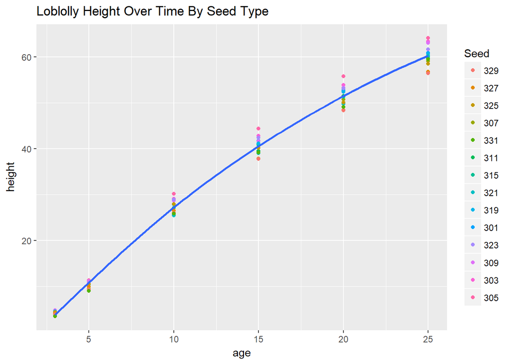

```r
# data("Loblolly")
ggplot(Loblolly, aes(y=height, x=age )) +
  geom_point(aes(colour = Seed))+
  geom_smooth(se = FALSE) +
  labs(title = "Loblolly Height Over Time By Seed Type")
```

## Frequency

We learned about frequency tables. Lets build some more specialized frequency tables with our data.First, lets check our range. Then, starting with height. Say we want to set our breaks every 5 feet.

```r
range(Loblolly$height)
```

```
## [1]  3.46 64.10
```

```r
breaks = seq(0, 65, by = 5)
(height.cut = cut(Loblolly$height, breaks, right=FALSE))
```

```
##  [1] [0,5)   [10,15) [25,30) [40,45) [50,55) [60,65) [0,5)   [10,15)
##  [9] [25,30) [40,45) [50,55) [60,65) [0,5)   [10,15) [30,35) [40,45)
## [17] [55,60) [60,65) [0,5)   [5,10)  [25,30) [35,40) [50,55) [55,60)
## [25] [0,5)   [10,15) [25,30) [40,45) [50,55) [60,65) [0,5)   [5,10)
## [33] [25,30) [35,40) [50,55) [55,60) [0,5)   [10,15) [25,30) [40,45)
## [41] [50,55) [60,65) [0,5)   [10,15) [25,30) [40,45) [50,55) [60,65)
## [49] [0,5)   [5,10)  [25,30) [35,40) [45,50) [60,65) [0,5)   [10,15)
## [57] [25,30) [40,45) [50,55) [60,65) [0,5)   [10,15) [25,30) [40,45)
## [65] [50,55) [55,60) [0,5)   [5,10)  [25,30) [35,40) [45,50) [55,60)
## [73] [0,5)   [5,10)  [25,30) [35,40) [45,50) [55,60) [0,5)   [5,10)
## [81] [25,30) [35,40) [45,50) [55,60)
## 13 Levels: [0,5) [5,10) [10,15) [15,20) [20,25) [25,30) ... [60,65)
```

Compute the frequency of heights in each sub-interval with the table function.

```r
(height.freq = table(height.cut))
```

```
## height.cut
##   [0,5)  [5,10) [10,15) [15,20) [20,25) [25,30) [30,35) [35,40) [40,45)
##      14       6       8       0       0      13       1       6       8
## [45,50) [50,55) [55,60) [60,65)
##       4       9       7       8
```

We apply the cbind function to print the result in column format.

```r
cbind(height.freq)
```

```
##         height.freq
## [0,5)            14
## [5,10)            6
## [10,15)           8
## [15,20)           0
## [20,25)           0
## [25,30)          13
## [30,35)           1
## [35,40)           6
## [40,45)           8
## [45,50)           4
## [50,55)           9
## [55,60)           7
## [60,65)           8
```

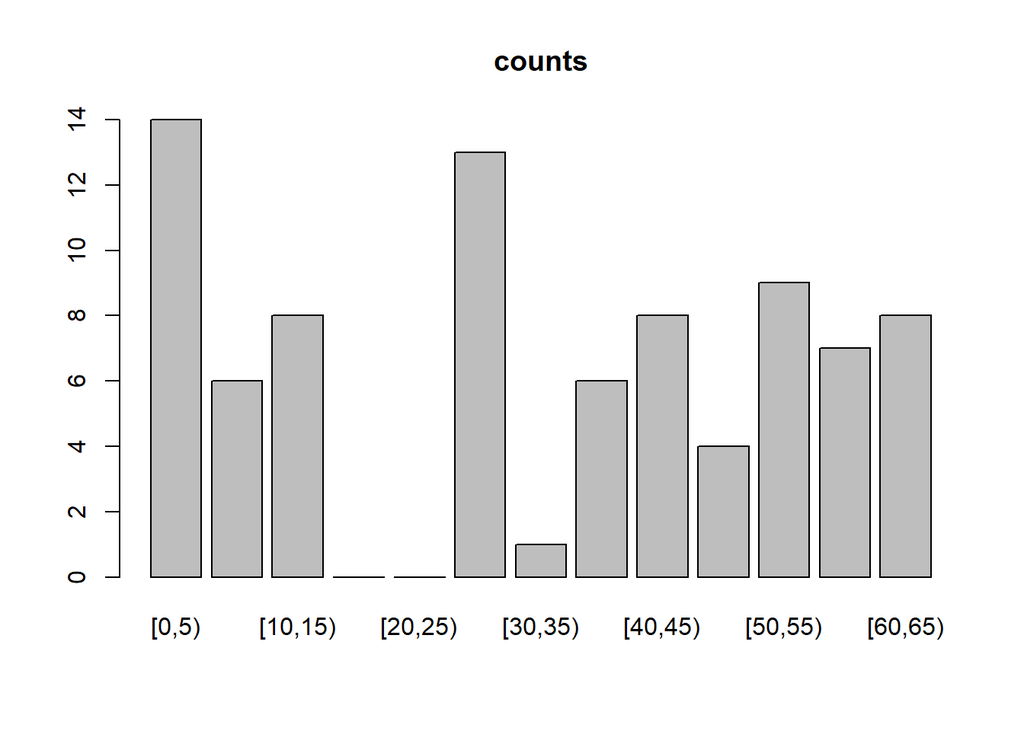

```r
barplot(height.freq, main = "counts")
```

```r
(h.relFreq <- prop.table(height.freq))
```

```
## height.cut
##      [0,5)     [5,10)    [10,15)    [15,20)    [20,25)    [25,30)
## 0.16666667 0.07142857 0.09523810 0.00000000 0.00000000 0.15476190
##    [30,35)    [35,40)    [40,45)    [45,50)    [50,55)    [55,60)
## 0.01190476 0.07142857 0.09523810 0.04761905 0.10714286 0.08333333
##    [60,65)
## 0.09523810
```

```r
(cumulative.height <- signif(cumsum(h.relFreq), digits = 2))
```

```
##   [0,5)  [5,10) [10,15) [15,20) [20,25) [25,30) [30,35) [35,40) [40,45)
##    0.17    0.24    0.33    0.33    0.33    0.49    0.50    0.57    0.67
## [45,50) [50,55) [55,60) [60,65)
##    0.71    0.82    0.90    1.00
```

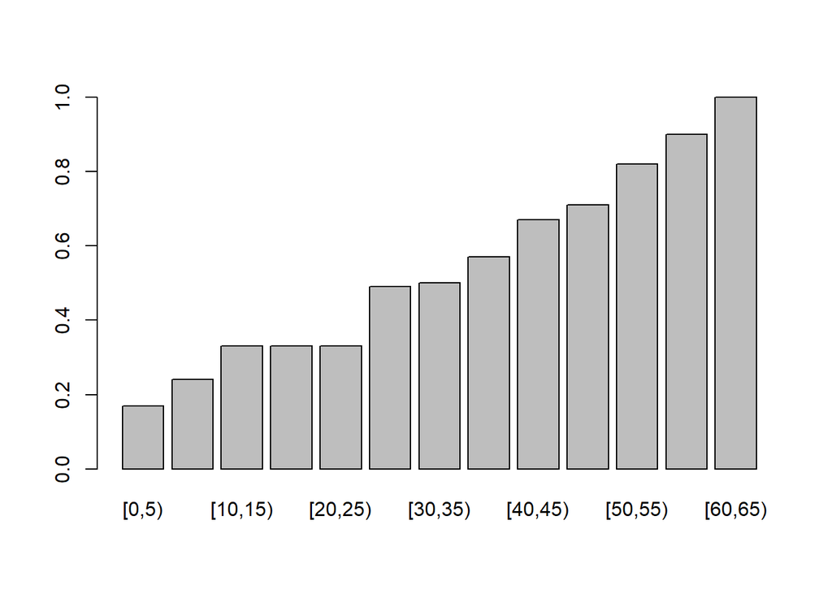

```r
barplot(cumulative.height)
```

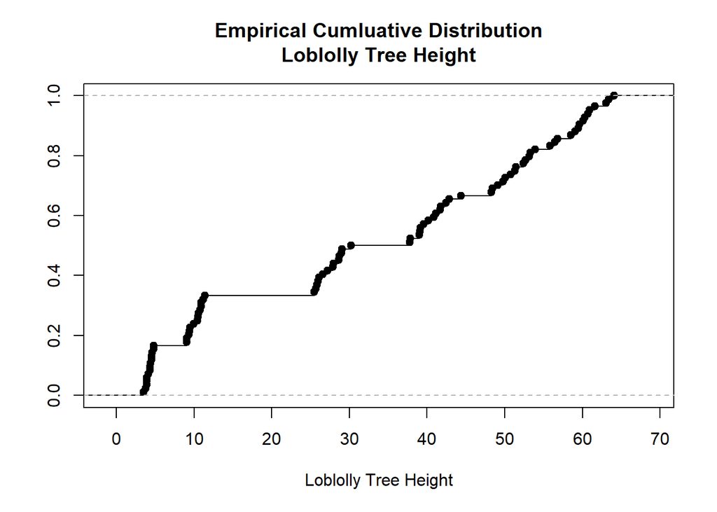

```r
height.ecdf <- ecdf(Loblolly$height)
plot(height.ecdf, xlab = 'Loblolly Tree Height', ylab = '', main = 'Empirical Cumluative Distribution\nLoblolly Tree Height')
```

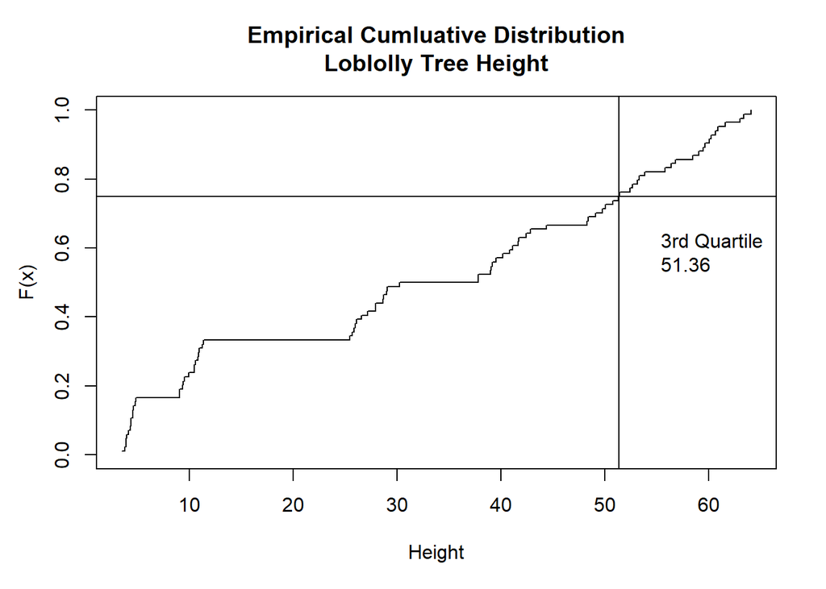

```r
height.ordered = sort(Loblolly$height)
plot(height.ordered, (1:84)/84, type = 's', ylim = c(0, 1), xlab = 'Height', ylab = '', main = 'Empirical Cumluative Distribution\nLoblolly Tree Height')
# mark the 3rd quartile
abline(v = 51.36, h = 0.75)

# add a legend
legend(52, 0.7, '3rd Quartile \n51.36', bty = "n")

# add the label on the y-axis
mtext(text = 'F(x)', side = 2, line = 2.5)
```

```r
(tab <- table(Loblolly$Seed))
```

```
##
## 329 327 325 307 331 311 315 321 319 301 323 309 303 305
##   6   6   6   6   6   6   6   6   6   6   6   6   6   6
```

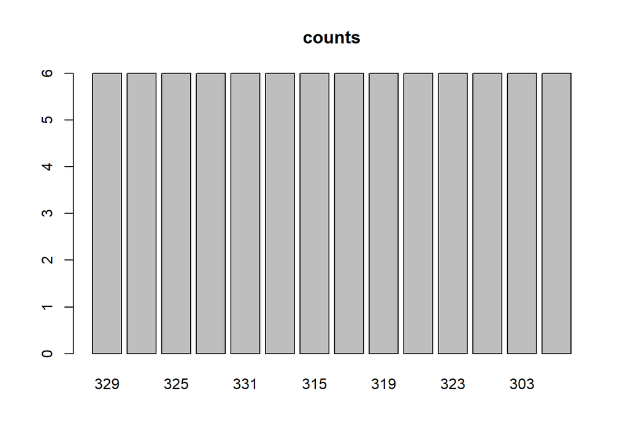

```r
barplot(tab, main = "counts")
```

```r
(relFreq <- signif(prop.table(tab),digits = 2))
```

```
##
##   329   327   325   307   331   311   315   321   319   301   323   309
## 0.071 0.071 0.071 0.071 0.071 0.071 0.071 0.071 0.071 0.071 0.071 0.071
##   303   305
## 0.071 0.071
```

```r
cumsum(relFreq)
```

```
##   329   327   325   307   331   311   315   321   319   301   323   309
## 0.071 0.142 0.213 0.284 0.355 0.426 0.497 0.568 0.639 0.710 0.781 0.852
##   303   305
## 0.923 0.994
```

## Measures of Central Tendency

### Mean

```r
mean(Loblolly$height)
```

```
## [1] 32.3644
```

```r
#or
sum(Loblolly$height)/nrow(Loblolly)
```

```
## [1] 32.3644
```

### Median

```r
median(Loblolly$height)
```

```
## [1] 34
```

```r
#or
n <- (nrow(Loblolly)+1)/2
(height.ordered[n]+height.ordered[n+1])/2
```

```
## [1] 34
```

### Mode

```r
Mode <- function(x) {
  ux <- unique(x)
  ux[which.max(tabulate(match(x, ux)))]
}

Mode(Loblolly$height)
```

```
## [1] 4.51
```

## Measures of Dispersion

### Variance

```r
var(Loblolly$height, y = NULL, na.rm = FALSE)
```

```
## [1] 427.3979
```

### Standard Deviation

```r
var(Loblolly$height, y = NULL, na.rm = FALSE)^.5
```

```
## [1] 20.6736
```